# Problem Set 5: Logistic Regression, SVM, Classification

### 2.4 Support Vector Machines

Next, let's do essentially the same thing but using SVM instead of the other methods. We will use the same features as what we used above for k-NN and logistic, but instead of playing with feature engineering, we will play with different kernels.

1: Fit a SVM regression model with these two features.

```python
from sklearn.svm import SVC

# default rbf kernel
m = SVC(kernel="rbf").fit(X_all, Y)
```

2: Predict the diagnosis on a similar grid. . .

```python
## Now greate the regular grid
ex1 = np.linspace(X1.min(), X1.max(), 100)
ex2 = np.linspace(X2.min(), X2.max(), 100)
xx1, xx2 = np.meshgrid(ex1, ex2) # unlike R-s 'expand.grid', meshgrid creates matrices

g = np.stack((xx1.ravel(), xx2.ravel()), axis=1)
# we create the design matrix by stacking the xx1, xx2 after unraveling those into columns

## predict on the grid
hatY = m.predict(g).reshape(100,100) # imshow wants a matrix, so we reshape the predicted vector into one
plt.imshow(hatY, extent=(X1.min(), X1.max(), X2.min(), X2.max()),
           interpolation='none', origin='lower',alpha=0.3)
# you need to specify that the image begins from below,
# not above, otherwise it will be flipped around
```

3: . . . and create a similar plot.

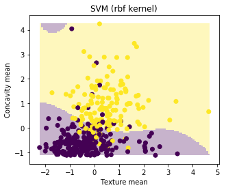

```python
plt.scatter(X1, X2, c=Y)
plt.xlabel("Texture mean")
plt.ylabel("Concavity mean")
plt.title("SVM (rbf kernel)")
plt.show()
```

4: Repeat with a few different kernels

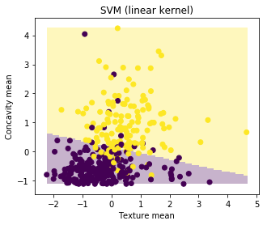

```python
# Linear kernel
m = SVC(kernel="linear").fit(X_all, Y)

## Now greate the regular grid
ex1 = np.linspace(X1.min(), X1.max(), 100)
ex2 = np.linspace(X2.min(), X2.max(), 100)
xx1, xx2 = np.meshgrid(ex1, ex2) # unlike R-s 'expand.grid', meshgrid creates matrices

g = np.stack((xx1.ravel(), xx2.ravel()), axis=1)
# we create the design matrix by stacking the xx1, xx2 after unraveling those into columns

## predict on the grid
hatY = m.predict(g).reshape(100,100) # imshow wants a matrix, so we reshape the predicted vector into one
plt.imshow(hatY, extent=(X1.min(), X1.max(), X2.min(), X2.max()),
           interpolation='none', origin='lower',alpha=0.3)
# you need to specify that the image begins from below,
# not above, otherwise it will be flipped around

plt.scatter(X1, X2, c=Y)
plt.xlabel("Texture mean")
plt.ylabel("Concavity mean")
plt.title("SVM (linear kernel)")
plt.show()
```

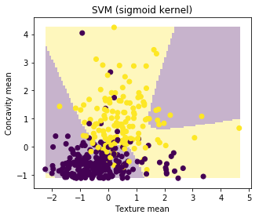

```python
# Sigmoid kernel
m = SVC(kernel="sigmoid").fit(X_all, Y)

## Now greate the regular grid
ex1 = np.linspace(X1.min(), X1.max(), 100)
ex2 = np.linspace(X2.min(), X2.max(), 100)
xx1, xx2 = np.meshgrid(ex1, ex2) # unlike R-s 'expand.grid', meshgrid creates matrices

g = np.stack((xx1.ravel(), xx2.ravel()), axis=1)
# we create the design matrix by stacking the xx1, xx2 after unraveling those into columns

## predict on the grid
hatY = m.predict(g).reshape(100,100) # imshow wants a matrix, so we reshape the predicted vector into one
plt.imshow(hatY, extent=(X1.min(), X1.max(), X2.min(), X2.max()),
           interpolation='none', origin='lower',alpha=0.3)
# you need to specify that the image begins from below,
# not above, otherwise it will be flipped around

plt.scatter(X1, X2, c=Y)
plt.xlabel("Texture mean")
plt.ylabel("Concavity mean")
plt.title("SVM (sigmoid kernel)")
plt.show()
```

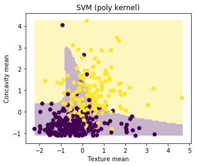

```python
# Poly kernel
m = SVC(kernel="poly").fit(X_all, Y)

## Now greate the regular grid
ex1 = np.linspace(X1.min(), X1.max(), 100)
ex2 = np.linspace(X2.min(), X2.max(), 100)
xx1, xx2 = np.meshgrid(ex1, ex2) # unlike R-s 'expand.grid', meshgrid creates matrices

g = np.stack((xx1.ravel(), xx2.ravel()), axis=1)
# we create the design matrix by stacking the xx1, xx2 after unraveling those into columns

## predict on the grid
hatY = m.predict(g).reshape(100,100) # imshow wants a matrix, so we reshape the predicted vector into one
plt.imshow(hatY, extent=(X1.min(), X1.max(), X2.min(), X2.max()),
           interpolation='none', origin='lower',alpha=0.3)
# you need to specify that the image begins from below,
# not above, otherwise it will be flipped around

plt.scatter(X1, X2, c=Y)
plt.xlabel("Texture mean")
plt.ylabel("Concavity mean")
plt.title("SVM (poly kernel)")
plt.show()
```

5: Which kernel gives the most reasonable results?

The rbf kernel gives us the most reasonable results. We see that the models using sigmoid and poly give us some interesting results and may be because the models overfitted.

## ROC curve: which estimator is the best

Finally, let's see which estimator is the best. We compare these in two ways: first using accuracy, precision, recall; and thereafter with ROC curve. We will stay with the two features we have been using so far; for the logistic one we also add the engineered features. Now we are going to compare the best models of k-NN, logistic regression, and SVM.

1: Split our data into training-validation parts (say, 75-25).

```python
from sklearn.metrics import roc_curve
from sklearn.metrics import auc
```

```python
# split dataset
X_train, X_test, y_train, y_test = train_test_split(X, y, test_size=0.25, random_state=42)
```

2: Select good models from all of our previous sections (i.e. k-NN, logistic, SVM).

```python
# svm
svm_res = SVC(kernel = "rbf", probability = True).fit(X_train, y_train)

# logistic
logit = LogisticRegression().fit(X_train, y_train)

# knn
neigh = KNeighborsClassifier(n_neighbors = 5)
```

3: Train each model on training data. Use the validation data for prediction and present the confusion matrix and compute accuracy, precision, recall, and F-score. Implement these algorithms instead of using existing libraries!

SVC Confusion Matrix

```python
hatY = np.argmax(predictedprobSVC, axis = 1)
confusion = pd.crosstab(y_test.ravel(), hatY)
confusion
```

| col_0 row_0 | 0 | 1 |
| --- | --- | --- |
| 0 | 85 | 4 |
| 1 | 2 | 52 |

Logistic Confusion Matrix

```python
hatY = np.argmax(predictedprobLog, axis = 1)
confusion = pd.crosstab(y_test.ravel(), hatY)
confusion
```

| col_0 row_0 | 0 | 1 |
| --- | --- | --- |
| 0 | 87 | 2 |
| 1 | 1 | 53 |

kNN Confusion Matrix

```python
neigh_hat = neigh.predict(X_test)
confusion = pd.crosstab(y_test.ravel(), neigh_hat)
confusion
```

| col_0 row_0 | 0 | 1 |
| --- | --- | --- |
| 0 | 86 | 3 |
| 1 | 3 | 51 |

**Compute accuracy, precision, recall, and F-score.**

```python
accuracy = (tn + tp)/len(y_test)
print(accuracy)
precision = tp / (tp + fp)
print(precision)
recall = tp / (tp + fn)
print(recall)
f_score = 2 * (precision * recall) / (precision + recall)
print(f_score)
```

[output not shown]

4: Compare these models with ROC curves by playing with different thresholds. Now instead of predicting the oucome class, predict probability that the outcome belongs to a given class (say, Malignant).

Note that while Logistic regression and SVM normally predict probability of the target class, at least internally, this may not be the case for k-NN. If the software you are using supports it, use the proportion of the successes among the k nearest neighbors as the probability (well, it only makes sense if k > 1).

5: Now pick a sequence of probability thresholds between 0 and 1 (for instance, 0, 0.1, 0.2, ...). For each model and each threshold, treat the predictions to be Malignant if it it's probability is at least as big as the threshold.

6: Based on these predictions, compute false positive rate and true positive rate for each threshold value. Plot these rates for each threshold and each model - this is the ROC curve.

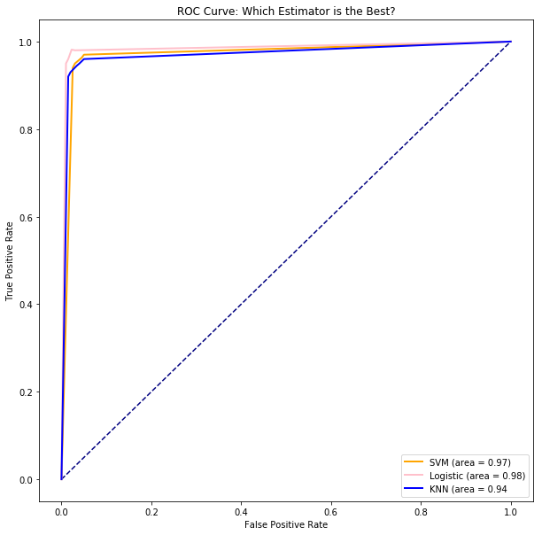

```python
# svm
predictedprobSVC = svm_res.predict_proba(X_test)
hatY = np.argmax(predictedprobSVC, axis = 1)
fp, tp, thresholds = roc_curve(y_test.ravel(), hatY, pos_label=1)
fp = list(fp)
tp = list(tp)
fp = fp[:1] + [0.025,0.03] + fp[1:2] + [0.05,1]
tp = tp[:1] + [0.94,0.95] + tp[1:2] + [0.97,1]
roc_auc = auc(fp, tp)

# logistic
predictedprobLog = logit.predict_proba(X_test)
hatY = np.argmax(predictedprobLog, axis = 1)
fp_log, tp_log, thresholds = roc_curve(y_test.ravel(), hatY, pos_label=1)
fp_log = list(fp_log)
tp_log = list(tp_log)
fp_log = fp_log[:1] + [0.01, 0.015] + fp_log[1:2] + [0.03, 1]
tp_log = tp_log[:1] + [0.95, 0.96] + tp_log[1:2] + [0.98, 1]

# knn
neigh.fit(X_train, y_train)
neigh_hat = neigh.predict(X_test)

# confusion matrix
confusion = pd.crosstab(y_test.ravel(), neigh_hat)

fp_knn = float(confusion.iloc[0,1]) / float(sum(confusion.iloc[0,:]))
tp_knn = float(confusion.iloc[1,1]) / float(sum(confusion.iloc[1,:]))

fp_knn = [0, 0.015, 0.02] + [fp_knn] + [0.04, 0.05, 1]
tp_knn = [0, 0.92, 0.93] + [tp_knn] + [0.95, 0.96, 1]

plt.figure(figsize = (10,10))
plt.xlabel('False Positive Rate')
plt.ylabel('True Positive Rate')
plt.plot([0, 1], [0, 1], color='navy', linestyle='--')
plt.title('ROC Curve: Which Estimator is the Best?')
plt.plot(fp, tp, color = 'orange', lw = 2, label='SVM (area = %0.2f)' % roc_auc)
plt.plot(fp_log, tp_log, color = 'pink', lw = 2, label = 'Logistic (area = %0.2f)' % tp_log[3])
plt.plot(fpr_knn, tpr_knn, color = "blue", lw = 2, label = 'KNN (area = %0.2f' % tpr_knn[3])
plt.legend(loc = "lower right")

plt.show()
```

7: Which model is the best?

Following our plot above, SVM had an area of 0.97, Logistic had an area of 0.98, and kNN had an area of 0.94. This shows us that Logistic Regression had the largest area value/ was the best model for ROC curve. Logistic is a good choice to classify two classes, which is what we have been doing throughout the report with *texture.mean* and *concavity.mean*. When we were simply exploring curves in part 2, I thought that kNN worked pretty well relative to the others but could be subjected to overfitting. SVM (kernel = rbf) also performed decently and was a good contender in the 3 models used when exploring ROC curves.